# Simulation (spatial scenarios)

Alba Fuster Alonso

# Introduction

Simulation of three different spatial scenarios: (1) Random sampling (2) Preferential sampling and (3) Areal data sampling. For each of them, biomass (response variable), bathymetry and effort (explanatory variables) were simulated.

The repository contains the development of three different simulations. All of them are pretended to simulate the catches per unit effort in a spatial area during a period of 1 year. The three cases are the following:

- Random sampling: simulation of an oceanographic survey with georeferenced data (independence in sampling).
- Preferential sampling: simulation of fisheries with georeferenced data (loss of independence in sampling).
- Areal data: simulation of preferential sampling with spatial lattice data.

The following variables are simulated for each scenario:

1. Biomass: response variable measured in tons.
2. Effort: quantitative and continuous explanatory variable, measuring the time during which the gear is active.
3. Bathymetry: quantitative and continuous explanatory variable, measures depth in meters.

# Georeferenced data: Random and Preferential sampling

In this first section georeferenced data for random and preferential sampling will be simulated.

## Simulate Log-Gaussian Cox Process

Firstly a random and preferential point pattern will be generated, a realization of the log-Gaussian Cox process. In this study the point pattern includes the fishing locations. Two point patterns are established: (1) random and (2) preferential. The random (1) corresponds to an oceanographic survey, while the preferential (2) corresponds to fishing data.

The rLGCP function of the spatstat package (version 1.64-1) was used to generate the point patterns as LGCP (Log Gaussian Cox Process). The Cox process is a Poisson process with intensity $\lambda(s)$, where $s$ is a space, and the log-Gaussian part modelling the logarithm of $\lambda$ log($\lambda(s)$).

The intensity ($\lambda$) is model as:

$$log(\lambda(s)) = \beta_{0} + S(s)$$
where $\beta_{0}$ is a fixed value that can be regarded as a global mean and $S(s)$ is a Gaussian spatial process with Matérn covariance and zero mean.

### Code of random sampling

```r
## Function parameters for data simulation
beta0.r <- 6.3
win.r <- owin(c(0, 1), c(0, 1))
nu.r <- 1
variance.r <- 0.0005
scale.r <- 0.1

## Apply the function
set.seed(12345)
lg.s.r <-
  rLGCP("exp", ### homogeneous LGCP with exponential covariance function
        beta0.r,
        var = variance.r,
        scale = scale.r,
        win = win.r) ### returns a list with the coordinates of the points
### and the value of lambda

Lam.r <- attr(lg.s.r, 'Lambda')
rf.s.r <- log(Lam.r$v)

xy.r <- cbind(lg.s.r$x, lg.s.r$y)[, 2:1]
n.r <- length(xy.r[, 1])
x.r <- xy.r[, 1]
y.r <- xy.r[, 2]

data.r <- data.frame(x = x.r, y = y.r)
coords.r <- rbind(data.r$x, data.r$y)
```

### Code of preferential sampling

```r
## Function parameters for data simulation
beta0.p <- 4
win.p <- owin(c(0, 1), c(0, 1))
nu.p <- 1
var.p <- 7.5
scale.p <- 0.15

## Apply the function
set.seed(12345)
lg.s.p <- rLGCP(
  'matern', ### inhomogeneous LGCP with Matern covariance function
  beta0.p,
  var = var.p,
  scale = scale.p,
  nu = nu.p,
  win = win.p
) ### returns a list with the coordinates of the points
### and the value of lambda

Lam.p <- attr(lg.s.p, 'Lambda')
rf.s.p <- log(Lam.p$v)

xy.p <- cbind(lg.s.p$x, lg.s.p$y)[, 2:1]
x.p <- xy.p[, 1]
y.p <- xy.p[, 2]

data.p <- data.frame(x = x.p, y = y.p)
coords.p <- rbind(data.p$x, data.p$y)
```

The results of the simulation are presented in Figure 1, red points represent the random pattern and yellow points the preferential pattern. The figure shows how random sampling is distributed over the entire spatial field, unlike preferential sampling, where points appear in areas of higher intensity ($\lambda$) (Figure 1).

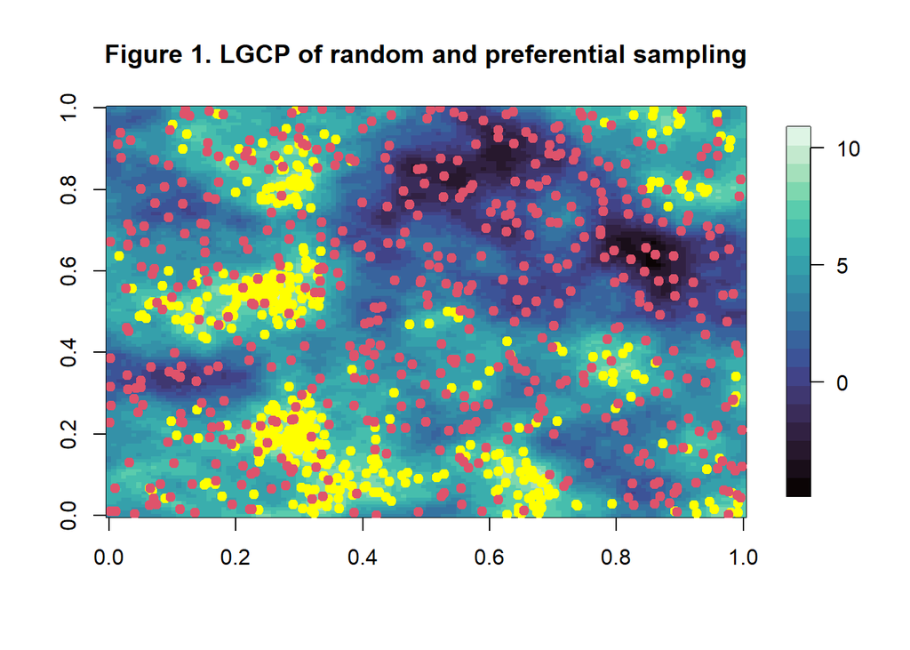

## Simulation of the study variables

As mentioned in the introduction, a total of three variables will be simulated. First, the response variable catches, which will be a direct measure of the biomass of the species. Secondly, the explanatory variables, which are fishing effort and bathymetry.

### Response variable

In order to know the biomass value in the whole space, the biomass of a target species will be simulated in a 1x1 window. From the raster obtained, the biomass value corresponding to previously simulated points will be extracted. Three distributions are used for the biomass simulation: poisson, gamma and gaussian, the poisson distribution is used for the simulation of zeros, while gamma and normal to simulate values in this case all positive.

```r
# Response variable: biomass
Lam.bat <- as.vector(rf.s.p) ### transform log lambda in vector
set.seed(12345)
abu <- vector()
for (i in 1:length(Lam.bat)) {
  if (Lam.bat[i] > 0 & Lam.bat[i] <= 4.469) {
    abu[i] <- rpois(1, 0.2) ### A poisson is used to simulate zeros.
  } else if (Lam.bat[i] > 4.469 & Lam.bat[i] <= 6.423) {
    abu[i] <- rgamma(1, 8, 0.05)
  } else {
    abu[i] <- rnorm(1, 350, 40)
  }
}
abu.image <- matrix(abu, ncol = 128, nrow = 128)
```

### Explanatory variables

For the bathymetry explanatory variable, it will be simulated in the same way as biomass in the whole spatial field.

```r
# Explanatory variable: bathymetry
set.seed(12345)
bath <- matrix(ncol = 128, nrow = 128)
for (i in 1:nrow(Lam.p$v)) {
  for (j in 1:ncol(Lam.p$v)) {
    a <- abu.image[i, j]
    if (a > 100 &a <=  250) {
      bath[i, j] <- rnorm(1, 300, 50)
      ### Assign values according to coordinates
    } else if (a > 250 &a <= 350) {
      bath[i,j] <- rnorm(1,400, 50)
    } else if (a >= 350) {
      bath[i,j] <- rnorm(1,500, 50)
    } else if (Lam.p$yrow[i] < 0.3) {
      bath[i, j] <- rgamma(1, 1, 0.04)
    } else {
      bath[i, j] <- rnorm(1, 850.05, 100)
    }
  }
}
bath.image <- matrix(bath, ncol = 128, nrow = 128)
```

In Figure 2, it is possible to observe the biomass and bathymetry values obtained throughout the spatial field (2.1 and 2.2, respectively). In addition, by superimposing the patterns of points, it is observed that preferential sampling appears in the areas of highest biomass and especially at intermediate bathymetry.

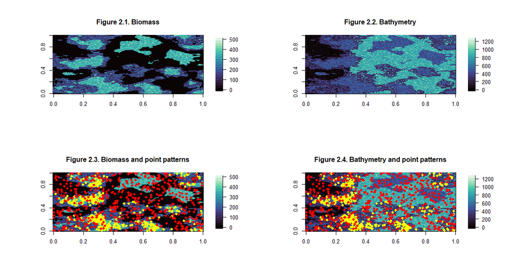

### Extraction of variable values related to point patterns

Bathymetry and biomass have been simulated over the entire spatial field, however, sampling has been carried out at specific points, therefore, the value of the variables at these points has to be extracted.

```r
# Extract the values of variables at point patterns
## Extract for preferential sampling
### Variable response: biomass
r.abu.p <- raster(abu.image) ### transform values of abudance in raster format
r.abu.p <- flip(t(r.abu.p), direction = 'y')
sp.p <- SpatialPoints(data.p) ### transform coords in a SpatialPoints
val1 <- extract(r.abu.p,sp.p) ### Extract values from the raster
### that coincide with the SpatialPoints.

### Variable explanatory: bathymetry
r.bath.p <- raster(bath.image)
r.bath.p <- flip(t(r.bath.p), direction='y')
val2 <- extract(r.bath.p,sp.p)

## Extract for random sampling
r.abu.r <- raster(abu.image)
r.abu.r <- flip(t(r.abu.r), direction = 'y')
sp.r <- SpatialPoints(data.r)
val3 <- extract(r.abu.r,sp.r)

r.bath.r <- raster(bath.image)
r.bath.r <- flip(t(r.bath.r), direction='y')
val4 <- extract(r.bath.r,sp.r)

# Include the variables in a dataframe
## Preferential sampling
data.variables.p <- data.frame(bath.p = val2, abu.p = val1)
## Random sampling
data.variables.r <- data.frame(bath.r = val4, abu.r = val3)
```

Finally, we added the fishing effort variable to the databanks. The effort variable has been simulated only in the coordinates of the point patterns for preferential and random sampling.

```r
# Effort for random sampling
set.seed(12345)
effort.r <- rnorm(535, 30, 0.5)

# Effort for preferential sampling
set.seed(12345)
effort.p <- vector()
for (i in 1:length(data.variables.p$abu.p)) {
  if (data.variables.p$abu.p[i] >= 0 &
      data.variables.p$abu.p[i] <= 100) {
    effort.p[i] <- rnorm(1, 25, 3)
  } else if (data.variables.p$abu.p[i] > 100 &
             data.variables.p$abu.p[i] <= 200.4) {
    effort.p[i] <- rnorm(1, 35, 3.5)
  } else {
    effort.p[i] <- rnorm(1, 45, 2.5)
  }
}

data.variables.r$effort.r <- effort.r
data.variables.p$effort.p <- effort.p
```

### Exploratory analysis of the simulated variables

Figure 3 displays the histograms and density curve for the biomass (response) and bathymetry (explanatory) variables for the scenarios: (1) random sampling (oceanographic campaign) and (2) preferential sampling (fisheries data).

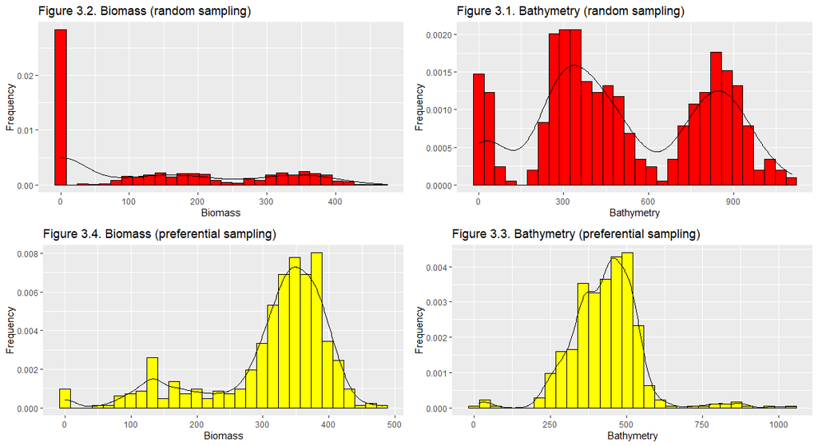

Regarding the relationship between the variables, a smooth function (loess technique) was used to visualize the behaviour between the different covariates and the response variable (Figure 4). Similarly, the spearman correlation coefficient was obtained to assess the correlation between the variables (Table 1 and Table 2).

Figure 4.1 and 4.2 illustrate the relationship between bathymetry and biomass for preferential and random sampling, respectively. In both cases it is evident that at bathymetries between 250 and 550 approximately there is a greater biomass of the species. For this reason, in the preferential sampling, most of the points are concentrated in these bathymetries range. Besides, the relationship between biomass and effort has a sigmoidal behaviour in the preferential sampling and is constant in the random sampling (Figure 4.3 and 4.4).

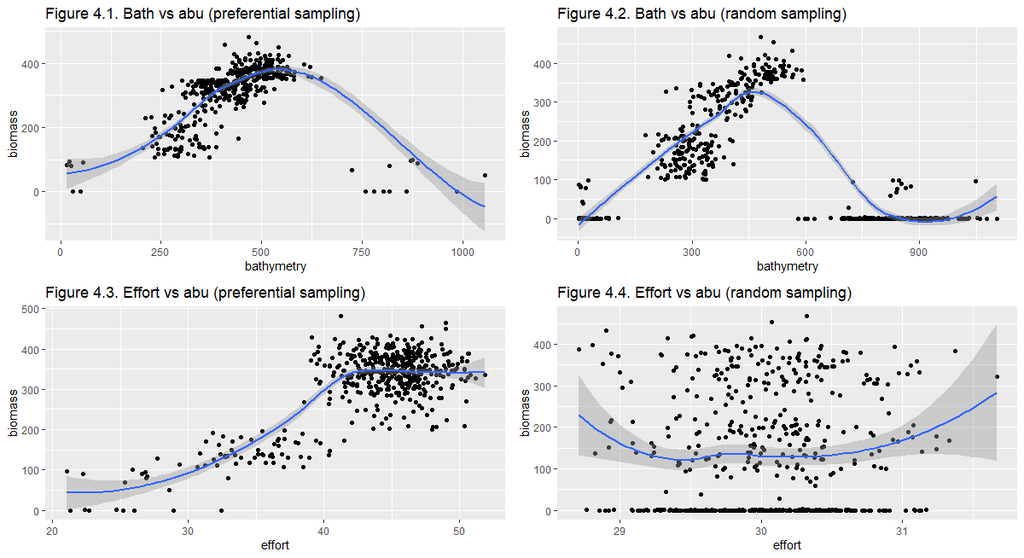

Spearman correlation (Random sampling)

|  | bath.r | abu.r | effort.r |
| --- | --- | --- | --- |
| bath.r | 1.0000000 | -0.3233232 | 0.0018893 |
| abu.r | -0.3233232 | 1.0000000 | 0.0279272 |
| effort.r | 0.0018893 | 0.0279272 | 1.0000000 |

Spearman correlation (Preferential sampling)

|  | bath.p | abu.p | effort.p |
| --- | --- | --- | --- |
| bath.p | 1.0000000 | 0.6313110 | 0.2002026 |
| abu.p | 0.6313110 | 1.0000000 | 0.3525611 |
| effort.p | 0.2002026 | 0.3525611 | 1.0000000 |

In the following figure, Figure 5, it is possible to observe the distribution in the spatial field of the biomass values. It may be observed how in the preferential sampling the points are concentrated in the areas of maximum biomass (5.1), while in the random sampling, an aim has been made to cover the entire spatial field (5.2).

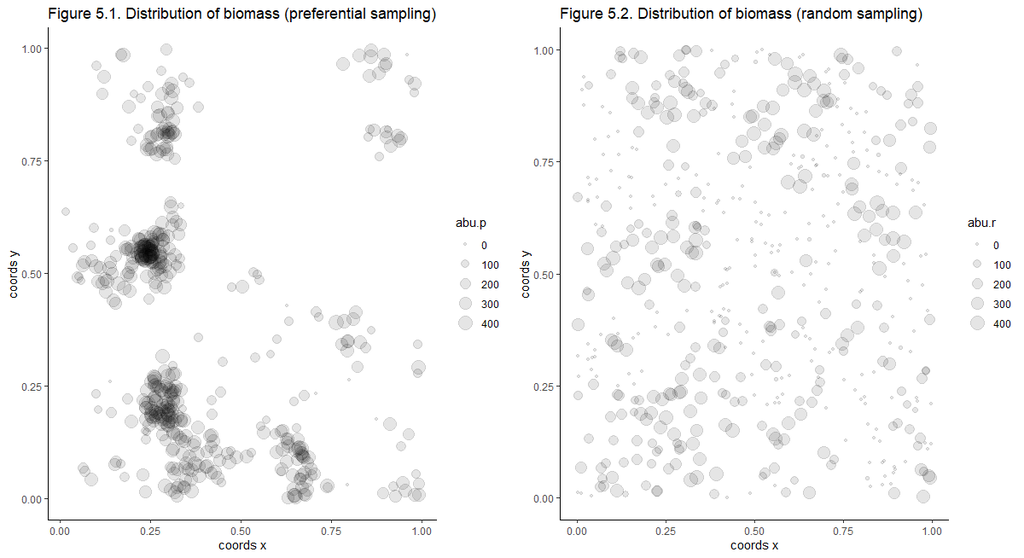

# Areal data

For the third and last scenario the 1x1 window of the previous scenarios will be taken and divided into a series of regular squares (100) (Figure 6). Moreover, the values of the variables will be grouped according to the values simulated in the preferential sampling.

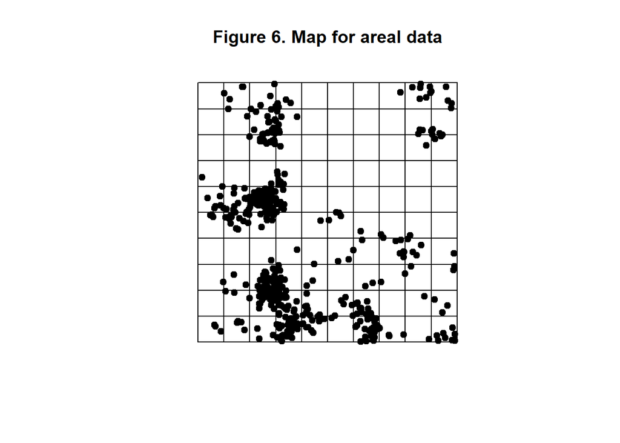

```r
# Generate a 10 x 10 matrix
mat <- matrix(1:100, nrow = 10, byrow = TRUE)
# Transform the matrix into a raster
raster <- raster(mat)
map <- rasterToPolygons(raster)
```

## Variable response: biomass

For all variables the same function is applied. First through a loop and a conditional we determine the position on the map of the coordinates associated with the preferential point pattern. Then, the biomass value of the points within each square is obtained and summed.

```r
# Sum of the biomass value for each of the squares
areal_data <- seq(0, 1, 0.1) # square sides
sum_abu.p <- vector()
n <- 1

for (i in (length(areal_data)):2) {
  for (j in 1:(length(areal_data) - 1)) {
    # Conditional to know where you are on the map
    cond <- which(
      data.p$x >= areal_data[j] &
        data.p$x < areal_data[j + 1] &
        data.p$y < areal_data[i] &
        data.p$y >= areal_data[i - 1]
    )
    cap.grid <- data.variables.p$abu.p[cond]
    sum_abu.p[n] <- sum(cap.grid) ## Sum of biomass
    n <- n + 1
  }
}

map$abu.p <- sum_abu.p
map$abu.p[is.na(map$abu.p)] <- 0 # Change NA to 0
map$layer <- NULL
```

## Explanatory variables: Effort and bathymetry

The same process as explained above is used.

```r
# Effort
sum_effort.p <- vector()
n <- 1
for (i in (length(areal_data)):2) {
  for (j in 1:(length(areal_data) - 1)) {
    cond <- which(
      data.p$x >= areal_data[j] &
        data.p$x < areal_data[j + 1] &
        data.p$y < areal_data[i] &
        data.p$y >= areal_data[i - 1]
    )
    cap.grid <- data.variables.p$effort.p[cond]
    sum_effort.p[n] <- sum(cap.grid)
    n <- n + 1
  }
}

map$effort.p <- sum_effort.p
map$effort.p[is.na(map$effort.p)] <- 0

# Bathymetry
mean_bat.p <- vector()
n <- 1
for (i in (length(areal_data)):2) {
  for (j in 1:(length(areal_data) - 1)) {
    cond <- which(
      data.p$x >= areal_data[j] &
        data.p$x < areal_data[j + 1] &
        data.p$y < areal_data[i] &
        data.p$y >= areal_data[i - 1]
    )
    cap.grid <- data.variables.p$bath.p[cond]
    mean_bat.p[n] <- mean(cap.grid)
    n <- n + 1
  }
}

map$bat.p <- mean_bat.p
map$bat.p[is.na(map$bat.p)] <- 0
```

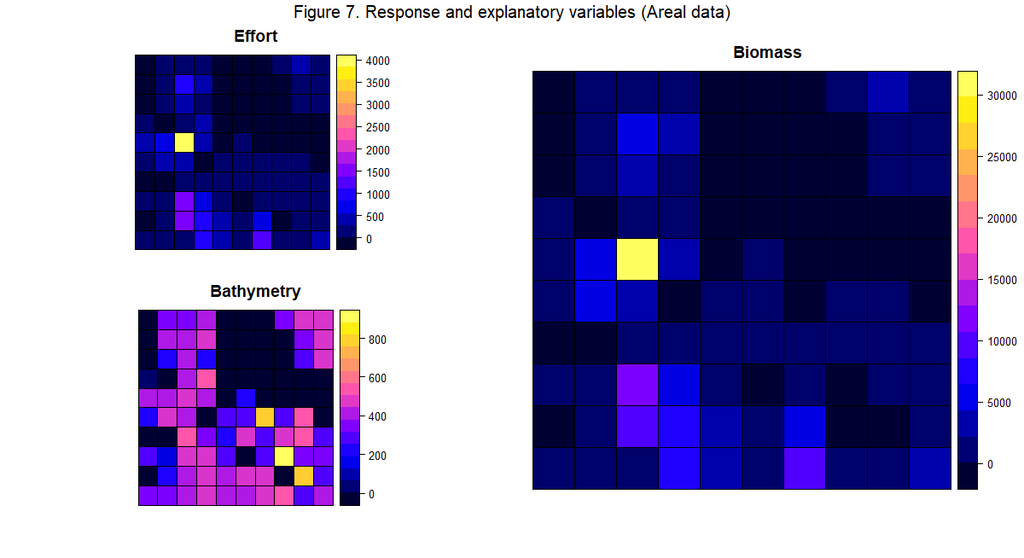

## Resize the square

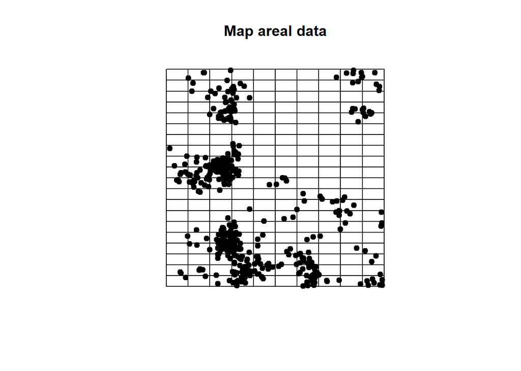

```r
mat <- matrix(1:200, nrow = 20, byrow = TRUE)
raster <- raster(mat)
map <- rasterToPolygons(raster)
```

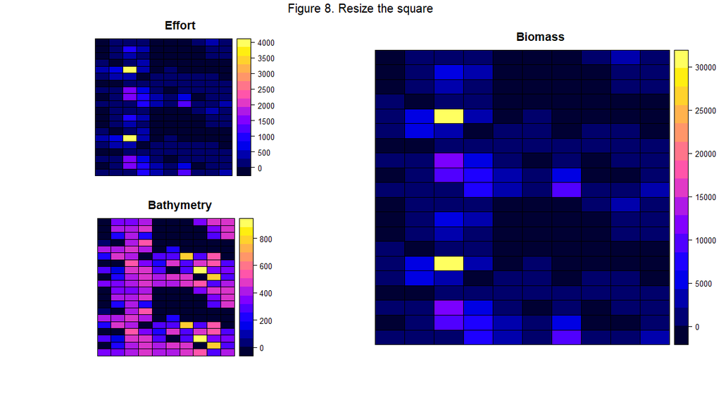

```r
# biomass
areal_data <- seq(0,1,0.1)
sum_abu.p <- vector()
n <- 1

for(i in (length(areal_data)):2) {
  for(j in 1:(length(areal_data)-1)) {
    cond <- which(
      data.p$x >= areal_data[j] &
        data.p$x < areal_data[j + 1] &
        data.p$y < areal_data[i] &
        data.p$y >= areal_data[i - 1]
    )
    cap.grid <- data.variables.p$abu.p[cond]
    sum_abu.p[n] <- sum(cap.grid)
    n <- n + 1
  }
}

map$abu.p <- sum_abu.p
map$abu.p[is.na(map$abu.p)] <- 0
map$layer <- NULL

# Effort
areal_data <- seq(0,1,0.1) # square sides
sum_effort.p <- vector()
n <- 1
for(i in (length(areal_data)):2) {
  for(j in 1:(length(areal_data)-1)) {
    cond <- which(
      data.p$x >= areal_data[j] &
        data.p$x < areal_data[j + 1] &
        data.p$y < areal_data[i] &
        data.p$y >= areal_data[i - 1]
    )
    cap.grid <- data.variables.p$effort.p[cond]
    sum_effort.p[n] <- sum(cap.grid)
    n <- n + 1
  }
}

map$effort.p <- sum_effort.p
map$effort.p[is.na(map$effort.p)] <- 0

# Bathymetry
areal_data <- seq(0,1,0.1)
mean_bat.p <- vector()
n <- 1
for(i in (length(areal_data)):2) {
  for(j in 1:(length(areal_data)-1)) {
    cond <- which(
      data.p$x >= areal_data[j] &
        data.p$x < areal_data[j + 1] &
        data.p$y < areal_data[i] &
        data.p$y >= areal_data[i - 1]
    )
    cap.grid <- data.variables.p$bath.p[cond]
    mean_bat.p[n] <- mean(cap.grid)
    n <- n + 1
  }
}

map$bat.p <- mean_bat.p
map$bat.p[is.na(map$bat.p)] <- 0
```